# 🏈 NFL Game Outcome Prediction using Historical Data

```python
import nfl_data_py as nfl
import matplotlib.pyplot as plt
import seaborn as sns
import pandas as pd
import numpy as np
from matplotlib.offsetbox import OffsetImage, AnnotationBbox
```

##### Creating dataset for previous years 2014-2023

```python
years = [2023,2022,2021,2020,2019,2018,2017,2016,2015,2014]
```

```python
df_prior_years = nfl.import_pbp_data(years, downcast=True, cache=False, alt_path=None)
```

```
2023 done.
2022 done.
2021 done.
2020 done.
2019 done.
2018 done.
2017 done.
2016 done.
2015 done.
2014 done.
Downcasting floats.
```

```python
df_prior_years.shape
```

```
(481740, 392)
```

##### Pulling data for 2024 (had to pull separately due to participation data is missing 2024 onwards)

```python
df_2024 = nfl.import_pbp_data([2024], include_participation=False)
```

```
2024 done.
Downcasting floats.
```

```python
df_2024.shape
```

```
(49492, 372)
```

##### merging all the data together

```python
df_all_years = pd.concat([df_prior_years, df_2024],ignore_index=True)
```

```python
df_all_years.shape
```

```
(531232, 392)
```

```python
df_all_years.columns
```

```
Index(['play_id', 'game_id', 'old_game_id_x', 'home_team', 'away_team',
       'season_type', 'week', 'posteam', 'posteam_type', 'defteam',
       ...
       'defense_players', 'n_offense', 'n_defense', 'ngs_air_yards',
       'time_to_throw', 'was_pressure', 'route', 'defense_man_zone_type',
       'defense_coverage_type', 'old_game_id'],
      dtype='object', length=392)
```

##### Check to see if all the data pulled from source without any issues

```python
df_all_years['season'].value_counts()
```

```
2021    49922
2023    49665
2024    49492
2022    49434
2015    48122
2020    47705
2016    47651
2014    47629
2019    47258
2017    47245
2018    47109
Name: season, dtype: int64
```

#### creating a new dataset with necessary columns for our model. Feature engineering some new columns that will hopefully make our algorithm perform better

```python
#creating an each game summary
nfl_stats = df_all_years.groupby(['season', 'week', 'away_team','home_team', 'posteam', 'defteam','season_type', 'home_coach','away_coach' ,'stadium', 'weather'], as_index = False).agg({'touchdown':'sum',
                                                                                                        'sack':'sum',
                                                                                                        'punt_attempt':'sum',
                                                                                                        'complete_pass':'sum',
                                                                                                        'pass_attempt':'sum',
                                                                                                        'passing_yards':'sum',
                                                                                                        'pass_touchdown':'sum',
                                                                                                        'rushing_yards':'sum',
                                                                                                        'interception':'sum',
                                                                                                        'series_success':'sum',
                                                                                                        'qb_hit':'sum',
                                                                                                        'yards_gained': lambda x: x[df_all_years['sack'] == 1].sum(),
                                                                                                        'qb_epa':'mean',
                                                                                                        'air_epa':'mean',
                                                                                                        'yac_epa':'mean',
                                                                                                        'drive_time_of_possession': lambda x: x.str.split(':').apply(lambda t: int(t[0]) * 60 + int(t[1]) if isinstance(t, list) else 0).sum(),
                                                                                                        'total_home_score': 'max',
                                                                                                        'total_away_score': 'max',
                                                                                                        'total_home_rush_epa':'mean',
                                                                                                        'total_home_pass_epa':'mean',
                                                                                                        'total_away_rush_epa':'mean',
                                                                                                        'total_away_pass_epa':'mean',
                                                                                                        'total_home_comp_air_epa': 'mean',
                                                                                                        'total_home_comp_yac_epa': 'mean',
                                                                                                        'total_away_comp_air_epa': 'mean',
                                                                                                        'total_away_comp_yac_epa':'mean',
                                                                                                        'total_home_epa': 'mean',
                                                                                                        'total_away_epa':'mean',
})
```

```python
nfl_stats.shape
```

```
(5934, 39)
```

```python
nfl_stats.rename(columns={'yards_gained': 'sack_yards'}, inplace=True)
```

##### Adding in a passing efficiency column to help our algorithm

```python
#weights for passing efficiency column
k1 = 20
k2 = 45
k3 = 1
```

```python
nfl_stats['team_passing_efficiency'] = (
    nfl_stats['passing_yards'] / nfl_stats['pass_attempt'] +
    nfl_stats['pass_touchdown'] * k1 -
    nfl_stats['interception'] * k2 +
    nfl_stats['qb_epa'] * k3

)
```

```python
columns_to_smooth = [ 'touchdown', 'sack', 'punt_attempt', 'complete_pass', 'pass_attempt',
       'passing_yards', 'pass_touchdown', 'rushing_yards', 'interception',
       'series_success', 'qb_hit', 'sack_yards', 'qb_epa', 'air_epa',
       'yac_epa', 'drive_time_of_possession', 'total_home_score',
       'total_away_score', 'total_home_rush_epa', 'total_home_pass_epa',
       'total_away_rush_epa', 'total_away_pass_epa', 'total_home_comp_air_epa',
       'total_home_comp_yac_epa', 'total_away_comp_air_epa',
       'total_away_comp_yac_epa', 'total_home_epa', 'total_away_epa',
       'team_passing_efficiency']

nfl_stats[[f'rolling_avg_{col}' for col in columns_to_smooth]] = (
    nfl_stats[columns_to_smooth]
    .rolling(window=3, min_periods=1)  # 5-game rolling window, min_periods avoids NaN for small sets
    .mean()
)
```

```python
nfl_stats.columns
```

```
Index(['season', 'week', 'away_team', 'home_team', 'posteam', 'defteam',
       'season_type', 'home_coach', 'away_coach', 'stadium', 'weather',
       'touchdown', 'sack', 'punt_attempt', 'complete_pass', 'pass_attempt',
       'passing_yards', 'pass_touchdown', 'rushing_yards', 'interception',
       'series_success', 'qb_hit', 'sack_yards', 'qb_epa', 'air_epa',
       'yac_epa', 'drive_time_of_possession', 'total_home_score',
       'total_away_score', 'total_home_rush_epa', 'total_home_pass_epa',
       'total_away_rush_epa', 'total_away_pass_epa', 'total_home_comp_air_epa',
       'total_home_comp_yac_epa', 'total_away_comp_air_epa',
       'total_away_comp_yac_epa', 'total_home_epa', 'total_away_epa',
       'team_passing_efficiency', 'rolling_avg_touchdown', 'rolling_avg_sack',
       'rolling_avg_punt_attempt', 'rolling_avg_complete_pass',
       'rolling_avg_pass_attempt', 'rolling_avg_passing_yards',
       'rolling_avg_pass_touchdown', 'rolling_avg_rushing_yards',
       'rolling_avg_interception', 'rolling_avg_series_success',
       'rolling_avg_qb_hit', 'rolling_avg_sack_yards', 'rolling_avg_qb_epa',
       'rolling_avg_air_epa', 'rolling_avg_yac_epa',
       'rolling_avg_drive_time_of_possession', 'rolling_avg_total_home_score',
       'rolling_avg_total_away_score', 'rolling_avg_total_home_rush_epa',
       'rolling_avg_total_home_pass_epa', 'rolling_avg_total_away_rush_epa',
       'rolling_avg_total_away_pass_epa',
       'rolling_avg_total_home_comp_air_epa',
       'rolling_avg_total_home_comp_yac_epa',
       'rolling_avg_total_away_comp_air_epa',
       'rolling_avg_total_away_comp_yac_epa', 'rolling_avg_total_home_epa',
       'rolling_avg_total_away_epa', 'rolling_avg_team_passing_efficiency'],
      dtype='object')
```

##### Creating our binary win/loss column that our model will predict

```python
condition = [((nfl_stats['total_home_score']) > (nfl_stats['total_away_score']))]
```

```python
values = [1]
```

```python
nfl_stats['home_win'] = np.select(condition, values)
```

```python
nfl_stats.head()
```

|  | season | week | away_team | home_team | posteam | defteam | season_type | home_coach | away_coach | stadium | ... | rolling_avg_total_away_rush_epa | rolling_avg_total_away_pass_epa | rolling_avg_total_home_comp_air_epa | rolling_avg_total_home_comp_yac_epa | rolling_avg_total_away_comp_air_epa | rolling_avg_total_away_comp_yac_epa | rolling_avg_total_home_epa | rolling_avg_total_away_epa | rolling_avg_team_passing_efficiency | home_win |
| --- | --- | --- | --- | --- | --- | --- | --- | --- | --- | --- | --- | --- | --- | --- | --- | --- | --- | --- | --- | --- | --- |
| 0 | 2014 | 1 | BUF | CHI | BUF | CHI | REG | Marc Trestman | Doug Marrone | Soldier Field | ... | 0.760195 | 2.825618 | 2.597690 | 0.505424 | -2.597690 | -0.505424 | -3.773171 | 3.773171 | -17.438576 | 0 |
| 1 | 2014 | 1 | BUF | CHI | CHI | BUF | REG | Marc Trestman | Doug Marrone | Soldier Field | ... | 0.589419 | 2.913367 | 2.901539 | 0.473004 | -2.901539 | -0.473004 | -3.863226 | 3.863226 | -30.281134 | 0 |
| 2 | 2014 | 1 | CAR | TB | CAR | TB | REG | Lovie Smith | Ron Rivera | Raymond James Stadium | ... | -0.962227 | 6.463803 | 1.816968 | -1.213375 | -1.816968 | 1.213375 | -5.319513 | 5.319513 | -4.672098 | 0 |
| 3 | 2014 | 1 | CAR | TB | TB | CAR | REG | Lovie Smith | Ron Rivera | Raymond James Stadium | ... | -2.791576 | 10.558266 | 0.784311 | -3.116508 | -0.784311 | 3.116508 | -6.940564 | 6.940564 | -13.945433 | 0 |
| 4 | 2014 | 1 | CIN | BAL | BAL | CIN | REG | John Harbaugh | Marvin Lewis | M&T Bank Stadium | ... | -3.531951 | 13.608039 | 2.771036 | -7.437724 | -2.771036 | 7.437724 | -9.428712 | 9.428712 | -6.165583 | 0 |

5 rows × 70 columns

##### Few data checks to make sure we're good to go

```python
nfl_stats.info()
```

```
<class 'pandas.core.frame.DataFrame'>
RangeIndex: 5934 entries, 0 to 5933
Data columns (total 70 columns):
 #   Column                                Non-Null Count  Dtype
---  ------                                --------------  -----
 0   season                                5934 non-null   int64
 1   week                                  5934 non-null   int32
 2   away_team                             5934 non-null   object
 3   home_team                             5934 non-null   object
 4   posteam                               5934 non-null   object
 5   defteam                               5934 non-null   object
 6   season_type                           5934 non-null   object
 7   home_coach                            5934 non-null   object
 8   away_coach                            5934 non-null   object
 9   stadium                               5934 non-null   object
```

[output cut: 62 more lines]

```python
nfl_stats.describe()
```

|  | season | week | touchdown | sack | punt_attempt | complete_pass | pass_attempt | passing_yards | pass_touchdown | rushing_yards | ... | rolling_avg_total_away_rush_epa | rolling_avg_total_away_pass_epa | rolling_avg_total_home_comp_air_epa | rolling_avg_total_home_comp_yac_epa | rolling_avg_total_away_comp_air_epa | rolling_avg_total_away_comp_yac_epa | rolling_avg_total_home_epa | rolling_avg_total_away_epa | rolling_avg_team_passing_efficiency | home_win |
| --- | --- | --- | --- | --- | --- | --- | --- | --- | --- | --- | --- | --- | --- | --- | --- | --- | --- | --- | --- | --- | --- |
| count | 5934.000000 | 5934.000000 | 5934.000000 | 5934.000000 | 5934.000000 | 5934.000000 | 5934.000000 | 5934.000000 | 5934.000000 | 5934.000000 | ... | 5934.000000 | 5934.000000 | 5934.000000 | 5934.000000 | 5934.000000 | 5934.000000 | 5934.000000 | 5934.000000 | 5934.000000 | 5934.000000 |
| mean | 2019.029997 | 9.643074 | 2.564880 | 2.375463 | 4.249916 | 22.035894 | 37.043816 | 246.995956 | 1.539602 | 113.901924 | ... | 0.056899 | 0.038110 | -0.195218 | -0.022843 | 0.195218 | 0.022843 | 0.288739 | -0.288739 | 1.473827 | 0.526795 |
| std | 3.162135 | 5.411283 | 1.423984 | 1.745258 | 1.888533 | 5.958468 | 8.679846 | 74.460297 | 1.160635 | 51.086605 | ... | 3.163657 | 6.508514 | 3.733066 | 4.028967 | 3.733066 | 4.028967 | 7.719840 | 7.719840 | 28.235748 | 0.499324 |
| min | 2014.000000 | 1.000000 | 0.000000 | 0.000000 | 0.000000 | 1.000000 | 3.000000 | 7.000000 | 0.000000 | -1.000000 | ... | -12.810637 | -21.868074 | -16.480707 | -16.501401 | -12.803903 | -14.807188 | -24.822454 | -29.557590 | -116.219247 | 0.000000 |
| 25% | 2016.000000 | 5.000000 | 2.000000 | 1.000000 | 3.000000 | 18.000000 | 31.000000 | 195.000000 | 1.000000 | 77.000000 | ... | -1.969746 | -4.422564 | -2.666528 | -2.691045 | -2.285978 | -2.643499 | -4.846746 | -5.469335 | -17.270579 | 0.000000 |
| 50% | 2019.000000 | 10.000000 | 2.000000 | 2.000000 | 4.000000 | 22.000000 | 37.000000 | 243.000000 | 1.000000 | 107.000000 | ... | 0.077458 | 0.036266 | -0.073859 | 0.012727 | 0.073859 | -0.012727 | 0.350300 | -0.350300 | 2.966119 | 1.000000 |
| 75% | 2022.000000 | 14.000000 | 3.000000 | 3.000000 | 5.000000 | 26.000000 | 43.000000 | 297.000000 | 2.000000 | 144.000000 | ... | 2.085759 | 4.344480 | 2.285978 | 2.643499 | 2.666528 | 2.691045 | 5.469335 | 4.846746 | 20.266218 | 1.000000 |
| max | 2024.000000 | 22.000000 | 10.000000 | 11.000000 | 13.000000 | 47.000000 | 72.000000 | 525.000000 | 7.000000 | 404.000000 | ... | 14.439356 | 24.196922 | 12.803903 | 14.807188 | 16.480707 | 16.501401 | 29.557590 | 24.822454 | 92.683971 | 1.000000 |

8 rows × 61 columns

```python
nfl_rolling = nfl_stats[['rolling_avg_touchdown', 'rolling_avg_sack',
       'rolling_avg_punt_attempt', 'rolling_avg_complete_pass',
       'rolling_avg_pass_attempt', 'rolling_avg_passing_yards',
       'rolling_avg_pass_touchdown', 'rolling_avg_rushing_yards',
       'rolling_avg_interception', 'rolling_avg_series_success',
       'rolling_avg_qb_hit', 'rolling_avg_sack_yards', 'rolling_avg_qb_epa',
       'rolling_avg_air_epa', 'rolling_avg_yac_epa',
       'rolling_avg_drive_time_of_possession', 'rolling_avg_total_home_score',
       'rolling_avg_total_away_score', 'rolling_avg_total_home_rush_epa',
       'rolling_avg_total_home_pass_epa', 'rolling_avg_total_away_rush_epa',
       'rolling_avg_total_away_pass_epa',
       'rolling_avg_total_home_comp_air_epa',
       'rolling_avg_total_home_comp_yac_epa',
       'rolling_avg_total_away_comp_air_epa',
       'rolling_avg_total_away_comp_yac_epa', 'rolling_avg_total_home_epa',
       'rolling_avg_total_away_epa', 'rolling_avg_team_passing_efficiency','home_win']]
```

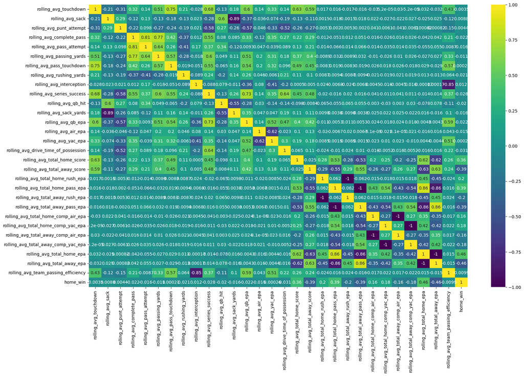

```python
plt.figure(figsize=(20,12))
sns.heatmap(nfl_rolling.corr(), cmap = 'viridis', annot=True)
```

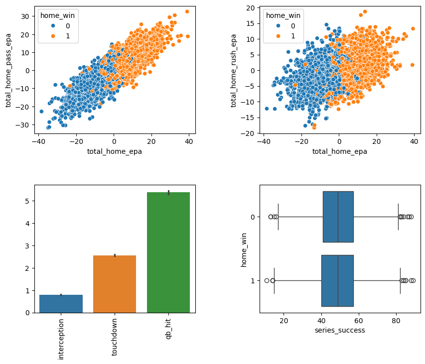

```python
fig = plt.figure(figsize= (10,8))
fig.subplots_adjust(hspace=0.4, wspace=0.4)
ax = fig.add_subplot(2, 2, 1)
sns.scatterplot(data=nfl_stats, x="total_home_epa", y="total_home_pass_epa", hue="home_win")
ax = fig.add_subplot(2, 2, 2)
sns.scatterplot(data=nfl_stats, x="total_home_epa", y="total_home_rush_epa", hue="home_win")
ax = fig.add_subplot(2, 2, 3)
sns.barplot(data = nfl_stats[['interception', 'touchdown', 'qb_hit']],ax=ax)
ax.set_xticklabels(ax.get_xticklabels(), rotation=90)
ax = fig.add_subplot(2, 2, 4)
sns.boxplot(data = nfl_stats, x = "series_success", y = "home_win", orient = 'h')
plt.show()
```

##### Rolling columns have some influence on the win/loss column as we can see in our correlation graph. There is a correlation of passing vs. rushing.

```python
from sklearn import preprocessing
```

```python
lb = preprocessing.LabelBinarizer()
```

```python
lb.fit_transform(nfl_stats['season_type'])
```

```
array([[1],
       [1],
       [1],
       ...,
       [0],
       [0],
       [0]])
```

```python
nfl_stats['season_type'].replace('REG', 0, inplace=True)
```

```python
nfl_stats['season_type'].replace('POST', 1, inplace=True)
```

##### Selecting features for our model

```python
new_list = nfl_stats.columns
print(new_list)
```

```
Index(['season', 'week', 'away_team', 'home_team', 'posteam', 'defteam',
       'season_type', 'home_coach', 'away_coach', 'stadium', 'weather',
       'touchdown', 'sack', 'punt_attempt', 'complete_pass', 'pass_attempt',
       'passing_yards', 'pass_touchdown', 'rushing_yards', 'interception',
       'series_success', 'qb_hit', 'sack_yards', 'qb_epa', 'air_epa',
       'yac_epa', 'drive_time_of_possession', 'total_home_score',
       'total_away_score', 'total_home_rush_epa', 'total_home_pass_epa',
       'total_away_rush_epa', 'total_away_pass_epa', 'total_home_comp_air_epa',
       'total_home_comp_yac_epa', 'total_away_comp_air_epa',
       'total_away_comp_yac_epa', 'total_home_epa', 'total_away_epa',
       'team_passing_efficiency', 'rolling_avg_touchdown', 'rolling_avg_sack',
       'rolling_avg_punt_attempt', 'rolling_avg_complete_pass',
       'rolling_avg_pass_attempt', 'rolling_avg_passing_yards',
       'rolling_avg_pass_touchdown', 'rolling_avg_rushing_yards',
       'rolling_avg_interception', 'rolling_avg_series_success',
       'rolling_avg_qb_hit', 'rolling_avg_sack_yards', 'rolling_avg_qb_epa',
       'rolling_avg_air_epa', 'rolling_avg_yac_epa',
       'rolling_avg_drive_time_of_possession', 'rolling_avg_total_home_score',
       'rolling_avg_total_away_score', 'rolling_avg_total_home_rush_epa',
       'rolling_avg_total_home_pass_epa', 'rolling_avg_total_away_rush_epa',
       'rolling_avg_total_away_pass_epa',
       'rolling_avg_total_home_comp_air_epa',
       'rolling_avg_total_home_comp_yac_epa',
       'rolling_avg_total_away_comp_air_epa',
       'rolling_avg_total_away_comp_yac_epa', 'rolling_avg_total_home_epa',
       'rolling_avg_total_away_epa', 'rolling_avg_team_passing_efficiency',
       'home_win'],
      dtype='object')
```

```python
features = ['rolling_avg_touchdown',
       'rolling_avg_sack', 'rolling_avg_punt_attempt',
       'rolling_avg_complete_pass', 'rolling_avg_pass_attempt',
       'rolling_avg_passing_yards', 'rolling_avg_pass_touchdown',
       'rolling_avg_rushing_yards', 'rolling_avg_interception',
       'rolling_avg_series_success', 'rolling_avg_qb_hit',
       'rolling_avg_sack_yards', 'rolling_avg_qb_epa', 'rolling_avg_air_epa',
       'rolling_avg_yac_epa', 'rolling_avg_drive_time_of_possession',
       'rolling_avg_total_home_rush_epa', 'rolling_avg_total_home_pass_epa',
       'rolling_avg_total_away_rush_epa', 'rolling_avg_total_away_pass_epa',
       'rolling_avg_total_home_comp_air_epa',
       'rolling_avg_total_home_comp_yac_epa',
       'rolling_avg_total_away_comp_air_epa',
       'rolling_avg_total_away_comp_yac_epa', 'rolling_avg_total_home_epa',
       'rolling_avg_total_away_epa', 'rolling_avg_team_passing_efficiency']
```

```python
target = 'home_win'
```

```python
X = nfl_stats.loc[nfl_stats['season'] != 2024, features].values
```

```python
y = nfl_stats.loc[nfl_stats['season'] != 2024, target].values
```

```python
from sklearn.model_selection import cross_val_score
from sklearn.linear_model import LogisticRegression
```

```python
log_model = LogisticRegression(max_iter=10000, random_state=42)
log_model.fit(X, y)
```

```
c:\Users\Ish20\OneDrive\Documents\Python Scripts\.venv\Lib\site-packages\sklearn\linear_model\_logistic.py:465: ConvergenceWarning: lbfgs failed to converge (status=1):
STOP: TOTAL NO. OF ITERATIONS REACHED LIMIT.

Increase the number of iterations (max_iter) or scale the data as shown in:
    https://scikit-learn.org/stable/modules/preprocessing.html
Please also refer to the documentation for alternative solver options:
    https://scikit-learn.org/stable/modules/linear_model.html#logistic-regression
  n_iter_i = _check_optimize_result(
```

```
LogisticRegression(max_iter=10000, random_state=42)
```

#### our model doesn't seem to be converging. lets try scaling the features to fix the issue

```python
from sklearn.preprocessing import StandardScaler
scaler = StandardScaler()
```

```python
X_scaled = scaler.fit_transform(X)
log_model.fit(X_scaled, y)
```

```
LogisticRegression(max_iter=10000, random_state=42)
```

```python
accuracy_scores = cross_val_score(log_model, X_scaled, y, cv=10)
log_losses = cross_val_score(log_model, X_scaled, y, cv=10, scoring='neg_log_loss')

print('Model Accuracy:', np.mean(accuracy_scores))
```

```
Model Accuracy: 0.7000549714835429
```

```python
from sklearn import svm
```

```python
svc_model = svm.SVC()
```

```python
svc_model.fit(X_scaled,y)
```

```
SVC()
```

```python
from sklearn.metrics import classification_report,confusion_matrix
```

```python
X_test = nfl_stats.loc[nfl_stats['season'] == 2024, features].values
y_test = nfl_stats.loc[nfl_stats['season'] == 2024, target].values
```

```python
X_test_scaled = scaler.transform(X_test)
```

```python
predictions = svc_model.predict(X_test_scaled)
```

```python
print(confusion_matrix(y_test,predictions))
```

```
[[166  88]
 [ 74 208]]
```

```python
print(classification_report(y_test,predictions))
```

```
              precision    recall  f1-score   support

           0       0.69      0.65      0.67       254
           1       0.70      0.74      0.72       282

    accuracy                           0.70       536
   macro avg       0.70      0.70      0.70       536
weighted avg       0.70      0.70      0.70       536
```

```python
param_grid_SVC = {'C': [0.1,1, 10, 100, 1000], 'gamma': [1,0.1,0.01,0.001,0.0001], 'kernel': ['rbf']}
```

```python
from sklearn.model_selection import GridSearchCV
```

```python
grid_SVC = GridSearchCV(svc_model,param_grid_SVC,refit=True,verbose=3)
```

```python
grid_SVC.fit(X_scaled,y)
```

[output not shown]

[output cut: 71 more lines]

```
[CV 1/5] END ....C=1000, gamma=0.01, kernel=rbf;, score=0.604 total time=   8.1s
[CV 2/5] END ....C=1000, gamma=0.01, kernel=rbf;, score=0.623 total time=   7.6s
[CV 3/5] END ....C=1000, gamma=0.01, kernel=rbf;, score=0.611 total time=   7.2s
[CV 4/5] END ....C=1000, gamma=0.01, kernel=rbf;, score=0.639 total time=   7.2s
[CV 5/5] END ....C=1000, gamma=0.01, kernel=rbf;, score=0.599 total time=   6.7s
[CV 1/5] END ...C=1000, gamma=0.001, kernel=rbf;, score=0.697 total time=   1.6s
[CV 2/5] END ...C=1000, gamma=0.001, kernel=rbf;, score=0.687 total time=   1.4s
[CV 3/5] END ...C=1000, gamma=0.001, kernel=rbf;, score=0.711 total time=   1.6s
[CV 4/5] END ...C=1000, gamma=0.001, kernel=rbf;, score=0.694 total time=   1.6s
[CV 5/5] END ...C=1000, gamma=0.001, kernel=rbf;, score=0.645 total time=   1.3s
[CV 1/5] END ..C=1000, gamma=0.0001, kernel=rbf;, score=0.707 total time=   0.7s
[CV 2/5] END ..C=1000, gamma=0.0001, kernel=rbf;, score=0.707 total time=   0.6s
[CV 3/5] END ..C=1000, gamma=0.0001, kernel=rbf;, score=0.725 total time=   0.8s
[CV 4/5] END ..C=1000, gamma=0.0001, kernel=rbf;, score=0.698 total time=   0.7s
[CV 5/5] END ..C=1000, gamma=0.0001, kernel=rbf;, score=0.652 total time=   0.7s
```

```
GridSearchCV(estimator=SVC(),
             param_grid={'C': [0.1, 1, 10, 100, 1000],
                         'gamma': [1, 0.1, 0.01, 0.001, 0.0001],
                         'kernel': ['rbf']},
             verbose=3)
```

```python
grid_SVC.best_params_
```

```
{'C': 1, 'gamma': 0.001, 'kernel': 'rbf'}
```

```python
grid_SVC.best_estimator_
```

```
SVC(C=1, gamma=0.001)
```

```python
grid_pred_SVC = grid_SVC.predict(X_test_scaled)
```

```python
print(confusion_matrix(y_test,grid_pred_SVC))
```

```
[[164  90]
 [ 79 203]]
```

```python
print(classification_report(y_test,grid_pred_SVC))
```

```
              precision    recall  f1-score   support

           0       0.67      0.65      0.66       254
           1       0.69      0.72      0.71       282

    accuracy                           0.68       536
   macro avg       0.68      0.68      0.68       536
weighted avg       0.68      0.68      0.68       536
```

```python
log_pred = log_model.predict(X_test_scaled)
```

```python
print(classification_report(y_test,log_pred))
```

```
              precision    recall  f1-score   support

           0       0.65      0.65      0.65       254
           1       0.69      0.69      0.69       282

    accuracy                           0.67       536
   macro avg       0.67      0.67      0.67       536
weighted avg       0.67      0.67      0.67       536
```

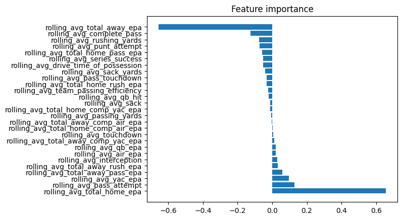

```python
fig, ax = plt.subplots()

feature_names = ['_'.join(feature_name.split('_')[3:]) for feature_name in features]

coef_ = log_model.coef_[0]

features_coef_sorted = sorted(zip(features, coef_), key=lambda x:x[-1], reverse=True)

features_sorted = [feature for feature, _ in features_coef_sorted]
coef_sorted = [coef for _, coef in features_coef_sorted]

ax.set_title('Feature importance')

ax.barh(features_sorted, coef_sorted);
plt.figure(figsize=(20,8))
plt.show();
```

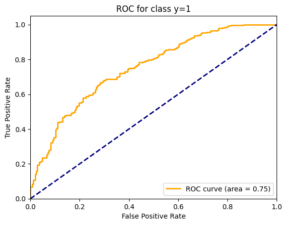

```python
y_pred_proba = log_model# Now, let's try to draw the ROC curve for class y=1
from sklearn.metrics import roc_curve, auc, roc_auc_score

# Calculate the fpr/tpr
y_pred_proba = log_model.predict_proba(X_test_scaled)[::,1]
fpr, tpr, _ = roc_curve(y_test, y_pred_proba)
roc_auc = auc(fpr, tpr)

# Do plot
plt.figure()
plt.plot(fpr, tpr, color="orange", linewidth=2,
    label="ROC curve (area = %0.2f)" % roc_auc)
plt.plot([0, 1], [0, 1], color="navy", linewidth=2, linestyle="--")
plt.xlim([0.0, 1.0])
plt.ylim([0.0, 1.05])
plt.xlabel("False Positive Rate")
plt.ylabel("True Positive Rate")
plt.title("ROC for class y=1")
plt.legend(loc="lower right")
```

```python
from sklearn.linear_model import SGDClassifier
```

```python
params = {
    "loss" : ["hinge", "log", "squared_hinge", "modified_huber", "perceptron"],
    "alpha" : [0.0001, 0.001, 0.01, 0.1],
    "penalty" : ["l2", "l1", "elasticnet", "none"],
}

#create the model
SGDC_model = SGDClassifier(random_state=42, max_iter=1000, tol=1e-3)
grid_SGDC = GridSearchCV(SGDC_model, param_grid=params, cv=5, scoring='accuracy', verbose=3)

#fit the model
grid_SGDC.fit(X_scaled, y)

print(grid_SGDC.best_params_)
print(grid_SGDC.best_estimator_)
```

[output not shown]

[output cut: 86 more lines]

```
[CV 1/5] END ...alpha=0.001, loss=log, penalty=l1;, score=nan total time=   0.0s
[CV 2/5] END ...alpha=0.001, loss=log, penalty=l1;, score=nan total time=   0.0s
[CV 3/5] END ...alpha=0.001, loss=log, penalty=l1;, score=nan total time=   0.0s
[CV 4/5] END ...alpha=0.001, loss=log, penalty=l1;, score=nan total time=   0.0s
[CV 5/5] END ...alpha=0.001, loss=log, penalty=l1;, score=nan total time=   0.0s
[CV 1/5] END alpha=0.001, loss=log, penalty=elasticnet;, score=nan total time=   0.0s
[CV 2/5] END alpha=0.001, loss=log, penalty=elasticnet;, score=nan total time=   0.0s
[CV 3/5] END alpha=0.001, loss=log, penalty=elasticnet;, score=nan total time=   0.0s
[CV 4/5] END alpha=0.001, loss=log, penalty=elasticnet;, score=nan total time=   0.0s
[CV 5/5] END alpha=0.001, loss=log, penalty=elasticnet;, score=nan total time=   0.0s
[CV 1/5] END .alpha=0.001, loss=log, penalty=none;, score=nan total time=   0.0s
[CV 2/5] END .alpha=0.001, loss=log, penalty=none;, score=nan total time=   0.0s
[CV 3/5] END .alpha=0.001, loss=log, penalty=none;, score=nan total time=   0.0s
[CV 4/5] END .alpha=0.001, loss=log, penalty=none;, score=nan total time=   0.0s
[CV 5/5] END .alpha=0.001, loss=log, penalty=none;, score=nan total time=   0.0s
```

```
c:\Users\Ish20\OneDrive\Documents\Python Scripts\.venv\Lib\site-packages\sklearn\linear_model\_stochastic_gradient.py:738: ConvergenceWarning: Maximum number of iteration reached before convergence. Consider increasing max_iter to improve the fit.
  warnings.warn(
```

```
[CV 1/5] END alpha=0.001, loss=squared_hinge, penalty=l2;, score=0.578 total time=   0.1s
```

```
c:\Users\Ish20\OneDrive\Documents\Python Scripts\.venv\Lib\site-packages\sklearn\linear_model\_stochastic_gradient.py:738: ConvergenceWarning: Maximum number of iteration reached before convergence. Consider increasing max_iter to improve the fit.
  warnings.warn(
```

```
[CV 2/5] END alpha=0.001, loss=squared_hinge, penalty=l2;, score=0.592 total time=   0.2s
```

```
c:\Users\Ish20\OneDrive\Documents\Python Scripts\.venv\Lib\site-packages\sklearn\linear_model\_stochastic_gradient.py:738: ConvergenceWarning: Maximum number of iteration reached before convergence. Consider increasing max_iter to improve the fit.
  warnings.warn(
```

```
[CV 3/5] END alpha=0.001, loss=squared_hinge, penalty=l2;, score=0.576 total time=   0.2s
```

```
c:\Users\Ish20\OneDrive\Documents\Python Scripts\.venv\Lib\site-packages\sklearn\linear_model\_stochastic_gradient.py:738: ConvergenceWarning: Maximum number of iteration reached before convergence. Consider increasing max_iter to improve the fit.
  warnings.warn(
```

```
[CV 4/5] END alpha=0.001, loss=squared_hinge, penalty=l2;, score=0.589 total time=   0.1s
```

```
c:\Users\Ish20\OneDrive\Documents\Python Scripts\.venv\Lib\site-packages\sklearn\linear_model\_stochastic_gradient.py:738: ConvergenceWarning: Maximum number of iteration reached before convergence. Consider increasing max_iter to improve the fit.
  warnings.warn(
```

```
[CV 5/5] END alpha=0.001, loss=squared_hinge, penalty=l2;, score=0.579 total time=   0.1s
[CV 1/5] END alpha=0.001, loss=squared_hinge, penalty=l1;, score=0.582 total time=   0.0s
[CV 2/5] END alpha=0.001, loss=squared_hinge, penalty=l1;, score=0.598 total time=   0.0s
[CV 3/5] END alpha=0.001, loss=squared_hinge, penalty=l1;, score=0.600 total time=   0.0s
[CV 4/5] END alpha=0.001, loss=squared_hinge, penalty=l1;, score=0.597 total time=   0.0s
[CV 5/5] END alpha=0.001, loss=squared_hinge, penalty=l1;, score=0.599 total time=   0.0s
```

```
c:\Users\Ish20\OneDrive\Documents\Python Scripts\.venv\Lib\site-packages\sklearn\linear_model\_stochastic_gradient.py:738: ConvergenceWarning: Maximum number of iteration reached before convergence. Consider increasing max_iter to improve the fit.
  warnings.warn(
```

```
[CV 1/5] END alpha=0.001, loss=squared_hinge, penalty=elasticnet;, score=0.578 total time=   0.4s
```

```
c:\Users\Ish20\OneDrive\Documents\Python Scripts\.venv\Lib\site-packages\sklearn\linear_model\_stochastic_gradient.py:738: ConvergenceWarning: Maximum number of iteration reached before convergence. Consider increasing max_iter to improve the fit.
  warnings.warn(
```

```
[CV 2/5] END alpha=0.001, loss=squared_hinge, penalty=elasticnet;, score=0.592 total time=   0.4s
```

```
c:\Users\Ish20\OneDrive\Documents\Python Scripts\.venv\Lib\site-packages\sklearn\linear_model\_stochastic_gradient.py:738: ConvergenceWarning: Maximum number of iteration reached before convergence. Consider increasing max_iter to improve the fit.
  warnings.warn(
```

```
[CV 3/5] END alpha=0.001, loss=squared_hinge, penalty=elasticnet;, score=0.576 total time=   0.3s
```

```
c:\Users\Ish20\OneDrive\Documents\Python Scripts\.venv\Lib\site-packages\sklearn\linear_model\_stochastic_gradient.py:738: ConvergenceWarning: Maximum number of iteration reached before convergence. Consider increasing max_iter to improve the fit.
  warnings.warn(
```

```
[CV 4/5] END alpha=0.001, loss=squared_hinge, penalty=elasticnet;, score=0.589 total time=   0.3s
```

```
c:\Users\Ish20\OneDrive\Documents\Python Scripts\.venv\Lib\site-packages\sklearn\linear_model\_stochastic_gradient.py:738: ConvergenceWarning: Maximum number of iteration reached before convergence. Consider increasing max_iter to improve the fit.
  warnings.warn(
```

[output not shown]

[output cut: 31 more lines]

```
[CV 1/5] END ....alpha=0.01, loss=log, penalty=l1;, score=nan total time=   0.0s
[CV 2/5] END ....alpha=0.01, loss=log, penalty=l1;, score=nan total time=   0.0s
[CV 3/5] END ....alpha=0.01, loss=log, penalty=l1;, score=nan total time=   0.0s
[CV 4/5] END ....alpha=0.01, loss=log, penalty=l1;, score=nan total time=   0.0s
[CV 5/5] END ....alpha=0.01, loss=log, penalty=l1;, score=nan total time=   0.0s
[CV 1/5] END alpha=0.01, loss=log, penalty=elasticnet;, score=nan total time=   0.0s
[CV 2/5] END alpha=0.01, loss=log, penalty=elasticnet;, score=nan total time=   0.0s
[CV 3/5] END alpha=0.01, loss=log, penalty=elasticnet;, score=nan total time=   0.0s
[CV 4/5] END alpha=0.01, loss=log, penalty=elasticnet;, score=nan total time=   0.0s
[CV 5/5] END alpha=0.01, loss=log, penalty=elasticnet;, score=nan total time=   0.0s
[CV 1/5] END ..alpha=0.01, loss=log, penalty=none;, score=nan total time=   0.0s
[CV 2/5] END ..alpha=0.01, loss=log, penalty=none;, score=nan total time=   0.0s
[CV 3/5] END ..alpha=0.01, loss=log, penalty=none;, score=nan total time=   0.0s
[CV 4/5] END ..alpha=0.01, loss=log, penalty=none;, score=nan total time=   0.0s
[CV 5/5] END ..alpha=0.01, loss=log, penalty=none;, score=nan total time=   0.0s
```

```
c:\Users\Ish20\OneDrive\Documents\Python Scripts\.venv\Lib\site-packages\sklearn\linear_model\_stochastic_gradient.py:738: ConvergenceWarning: Maximum number of iteration reached before convergence. Consider increasing max_iter to improve the fit.
  warnings.warn(
```

```
[CV 1/5] END alpha=0.01, loss=squared_hinge, penalty=l2;, score=0.578 total time=   0.1s
```

```
c:\Users\Ish20\OneDrive\Documents\Python Scripts\.venv\Lib\site-packages\sklearn\linear_model\_stochastic_gradient.py:738: ConvergenceWarning: Maximum number of iteration reached before convergence. Consider increasing max_iter to improve the fit.
  warnings.warn(
```

```
[CV 2/5] END alpha=0.01, loss=squared_hinge, penalty=l2;, score=0.599 total time=   0.1s
```

```
c:\Users\Ish20\OneDrive\Documents\Python Scripts\.venv\Lib\site-packages\sklearn\linear_model\_stochastic_gradient.py:738: ConvergenceWarning: Maximum number of iteration reached before convergence. Consider increasing max_iter to improve the fit.
  warnings.warn(
```

```
[CV 3/5] END alpha=0.01, loss=squared_hinge, penalty=l2;, score=0.579 total time=   0.2s
```

```
c:\Users\Ish20\OneDrive\Documents\Python Scripts\.venv\Lib\site-packages\sklearn\linear_model\_stochastic_gradient.py:738: ConvergenceWarning: Maximum number of iteration reached before convergence. Consider increasing max_iter to improve the fit.
  warnings.warn(
```

```
[CV 4/5] END alpha=0.01, loss=squared_hinge, penalty=l2;, score=0.591 total time=   0.1s
```

```
c:\Users\Ish20\OneDrive\Documents\Python Scripts\.venv\Lib\site-packages\sklearn\linear_model\_stochastic_gradient.py:738: ConvergenceWarning: Maximum number of iteration reached before convergence. Consider increasing max_iter to improve the fit.
  warnings.warn(
```

```
[CV 5/5] END alpha=0.01, loss=squared_hinge, penalty=l2;, score=0.587 total time=   0.1s
[CV 1/5] END alpha=0.01, loss=squared_hinge, penalty=l1;, score=0.581 total time=   0.0s
[CV 2/5] END alpha=0.01, loss=squared_hinge, penalty=l1;, score=0.599 total time=   0.0s
[CV 3/5] END alpha=0.01, loss=squared_hinge, penalty=l1;, score=0.579 total time=   0.0s
[CV 4/5] END alpha=0.01, loss=squared_hinge, penalty=l1;, score=0.573 total time=   0.0s
[CV 5/5] END alpha=0.01, loss=squared_hinge, penalty=l1;, score=0.570 total time=   0.0s
```

```
c:\Users\Ish20\OneDrive\Documents\Python Scripts\.venv\Lib\site-packages\sklearn\linear_model\_stochastic_gradient.py:738: ConvergenceWarning: Maximum number of iteration reached before convergence. Consider increasing max_iter to improve the fit.
  warnings.warn(
```

```
[CV 1/5] END alpha=0.01, loss=squared_hinge, penalty=elasticnet;, score=0.578 total time=   0.4s
```

```
c:\Users\Ish20\OneDrive\Documents\Python Scripts\.venv\Lib\site-packages\sklearn\linear_model\_stochastic_gradient.py:738: ConvergenceWarning: Maximum number of iteration reached before convergence. Consider increasing max_iter to improve the fit.
  warnings.warn(
```

```
[CV 2/5] END alpha=0.01, loss=squared_hinge, penalty=elasticnet;, score=0.599 total time=   0.3s
```

```
c:\Users\Ish20\OneDrive\Documents\Python Scripts\.venv\Lib\site-packages\sklearn\linear_model\_stochastic_gradient.py:738: ConvergenceWarning: Maximum number of iteration reached before convergence. Consider increasing max_iter to improve the fit.
  warnings.warn(
```

```
[CV 3/5] END alpha=0.01, loss=squared_hinge, penalty=elasticnet;, score=0.579 total time=   0.3s
```

```
c:\Users\Ish20\OneDrive\Documents\Python Scripts\.venv\Lib\site-packages\sklearn\linear_model\_stochastic_gradient.py:738: ConvergenceWarning: Maximum number of iteration reached before convergence. Consider increasing max_iter to improve the fit.
  warnings.warn(
```

```
[CV 4/5] END alpha=0.01, loss=squared_hinge, penalty=elasticnet;, score=0.591 total time=   0.4s
```

```
c:\Users\Ish20\OneDrive\Documents\Python Scripts\.venv\Lib\site-packages\sklearn\linear_model\_stochastic_gradient.py:738: ConvergenceWarning: Maximum number of iteration reached before convergence. Consider increasing max_iter to improve the fit.
  warnings.warn(
```

[output not shown]

[output cut: 31 more lines]

```
[CV 1/5] END .....alpha=0.1, loss=log, penalty=l1;, score=nan total time=   0.0s
[CV 2/5] END .....alpha=0.1, loss=log, penalty=l1;, score=nan total time=   0.0s
[CV 3/5] END .....alpha=0.1, loss=log, penalty=l1;, score=nan total time=   0.0s
[CV 4/5] END .....alpha=0.1, loss=log, penalty=l1;, score=nan total time=   0.0s
[CV 5/5] END .....alpha=0.1, loss=log, penalty=l1;, score=nan total time=   0.0s
[CV 1/5] END alpha=0.1, loss=log, penalty=elasticnet;, score=nan total time=   0.0s
[CV 2/5] END alpha=0.1, loss=log, penalty=elasticnet;, score=nan total time=   0.0s
[CV 3/5] END alpha=0.1, loss=log, penalty=elasticnet;, score=nan total time=   0.0s
[CV 4/5] END alpha=0.1, loss=log, penalty=elasticnet;, score=nan total time=   0.0s
[CV 5/5] END alpha=0.1, loss=log, penalty=elasticnet;, score=nan total time=   0.0s
[CV 1/5] END ...alpha=0.1, loss=log, penalty=none;, score=nan total time=   0.0s
[CV 2/5] END ...alpha=0.1, loss=log, penalty=none;, score=nan total time=   0.0s
[CV 3/5] END ...alpha=0.1, loss=log, penalty=none;, score=nan total time=   0.0s
[CV 4/5] END ...alpha=0.1, loss=log, penalty=none;, score=nan total time=   0.0s
[CV 5/5] END ...alpha=0.1, loss=log, penalty=none;, score=nan total time=   0.0s
```

```
c:\Users\Ish20\OneDrive\Documents\Python Scripts\.venv\Lib\site-packages\sklearn\linear_model\_stochastic_gradient.py:738: ConvergenceWarning: Maximum number of iteration reached before convergence. Consider increasing max_iter to improve the fit.
  warnings.warn(
```

```
[CV 1/5] END alpha=0.1, loss=squared_hinge, penalty=l2;, score=0.560 total time=   0.1s
```

```
c:\Users\Ish20\OneDrive\Documents\Python Scripts\.venv\Lib\site-packages\sklearn\linear_model\_stochastic_gradient.py:738: ConvergenceWarning: Maximum number of iteration reached before convergence. Consider increasing max_iter to improve the fit.
  warnings.warn(
```

```
[CV 2/5] END alpha=0.1, loss=squared_hinge, penalty=l2;, score=0.605 total time=   0.1s
```

```
c:\Users\Ish20\OneDrive\Documents\Python Scripts\.venv\Lib\site-packages\sklearn\linear_model\_stochastic_gradient.py:738: ConvergenceWarning: Maximum number of iteration reached before convergence. Consider increasing max_iter to improve the fit.
  warnings.warn(
```

```
[CV 3/5] END alpha=0.1, loss=squared_hinge, penalty=l2;, score=0.586 total time=   0.2s
```

```
c:\Users\Ish20\OneDrive\Documents\Python Scripts\.venv\Lib\site-packages\sklearn\linear_model\_stochastic_gradient.py:738: ConvergenceWarning: Maximum number of iteration reached before convergence. Consider increasing max_iter to improve the fit.
  warnings.warn(
```

```
[CV 4/5] END alpha=0.1, loss=squared_hinge, penalty=l2;, score=0.584 total time=   0.1s
```

```
c:\Users\Ish20\OneDrive\Documents\Python Scripts\.venv\Lib\site-packages\sklearn\linear_model\_stochastic_gradient.py:738: ConvergenceWarning: Maximum number of iteration reached before convergence. Consider increasing max_iter to improve the fit.
  warnings.warn(
```

```
[CV 5/5] END alpha=0.1, loss=squared_hinge, penalty=l2;, score=0.549 total time=   0.1s
```

```
c:\Users\Ish20\OneDrive\Documents\Python Scripts\.venv\Lib\site-packages\sklearn\linear_model\_stochastic_gradient.py:738: ConvergenceWarning: Maximum number of iteration reached before convergence. Consider increasing max_iter to improve the fit.
  warnings.warn(
```

```
[CV 1/5] END alpha=0.1, loss=squared_hinge, penalty=l1;, score=0.571 total time=   0.4s
```

```
c:\Users\Ish20\OneDrive\Documents\Python Scripts\.venv\Lib\site-packages\sklearn\linear_model\_stochastic_gradient.py:738: ConvergenceWarning: Maximum number of iteration reached before convergence. Consider increasing max_iter to improve the fit.
  warnings.warn(
```

```
[CV 2/5] END alpha=0.1, loss=squared_hinge, penalty=l1;, score=0.606 total time=   0.4s
```

```
c:\Users\Ish20\OneDrive\Documents\Python Scripts\.venv\Lib\site-packages\sklearn\linear_model\_stochastic_gradient.py:738: ConvergenceWarning: Maximum number of iteration reached before convergence. Consider increasing max_iter to improve the fit.
  warnings.warn(
```

```
[CV 3/5] END alpha=0.1, loss=squared_hinge, penalty=l1;, score=0.594 total time=   0.3s
```

```
c:\Users\Ish20\OneDrive\Documents\Python Scripts\.venv\Lib\site-packages\sklearn\linear_model\_stochastic_gradient.py:738: ConvergenceWarning: Maximum number of iteration reached before convergence. Consider increasing max_iter to improve the fit.
  warnings.warn(
```

```
[CV 4/5] END alpha=0.1, loss=squared_hinge, penalty=l1;, score=0.579 total time=   0.3s
```

```
c:\Users\Ish20\OneDrive\Documents\Python Scripts\.venv\Lib\site-packages\sklearn\linear_model\_stochastic_gradient.py:738: ConvergenceWarning: Maximum number of iteration reached before convergence. Consider increasing max_iter to improve the fit.
  warnings.warn(
```

```
[CV 5/5] END alpha=0.1, loss=squared_hinge, penalty=l1;, score=0.558 total time=   0.3s
```

```
c:\Users\Ish20\OneDrive\Documents\Python Scripts\.venv\Lib\site-packages\sklearn\linear_model\_stochastic_gradient.py:738: ConvergenceWarning: Maximum number of iteration reached before convergence. Consider increasing max_iter to improve the fit.
  warnings.warn(
```

```
[CV 1/5] END alpha=0.1, loss=squared_hinge, penalty=elasticnet;, score=0.564 total time=   0.3s
```

```
c:\Users\Ish20\OneDrive\Documents\Python Scripts\.venv\Lib\site-packages\sklearn\linear_model\_stochastic_gradient.py:738: ConvergenceWarning: Maximum number of iteration reached before convergence. Consider increasing max_iter to improve the fit.
  warnings.warn(
```

```
[CV 2/5] END alpha=0.1, loss=squared_hinge, penalty=elasticnet;, score=0.607 total time=   0.4s
```

```
c:\Users\Ish20\OneDrive\Documents\Python Scripts\.venv\Lib\site-packages\sklearn\linear_model\_stochastic_gradient.py:738: ConvergenceWarning: Maximum number of iteration reached before convergence. Consider increasing max_iter to improve the fit.
  warnings.warn(
```

```
[CV 3/5] END alpha=0.1, loss=squared_hinge, penalty=elasticnet;, score=0.586 total time=   0.3s
```

```
c:\Users\Ish20\OneDrive\Documents\Python Scripts\.venv\Lib\site-packages\sklearn\linear_model\_stochastic_gradient.py:738: ConvergenceWarning: Maximum number of iteration reached before convergence. Consider increasing max_iter to improve the fit.
  warnings.warn(
```

```
[CV 4/5] END alpha=0.1, loss=squared_hinge, penalty=elasticnet;, score=0.582 total time=   0.4s
```

```
c:\Users\Ish20\OneDrive\Documents\Python Scripts\.venv\Lib\site-packages\sklearn\linear_model\_stochastic_gradient.py:738: ConvergenceWarning: Maximum number of iteration reached before convergence. Consider increasing max_iter to improve the fit.
  warnings.warn(
```

[output not shown]

[output not shown]

```python
grid_pred_SGDC = grid_SGDC.predict(X_test_scaled)
```

```python
print(confusion_matrix(y_test,grid_pred_SGDC))
```

```
[[158  96]
 [ 76 206]]
```

```python
print(classification_report(y_test,grid_pred_SGDC))
```

```
              precision    recall  f1-score   support

           0       0.68      0.62      0.65       254
           1       0.68      0.73      0.71       282

    accuracy                           0.68       536
   macro avg       0.68      0.68      0.68       536
weighted avg       0.68      0.68      0.68       536
```

```python
from sklearn.feature_selection import SelectKBest, f_classif, chi2, mutual_info_classif
from sklearn.pipeline import make_pipeline
```

```python
params_grid_2 = {'selectkbest__k': [1, 5, 10, 12, 15, 21], 'svc__C': [0.1,1, 10, 100, 1000], 'svc__gamma': [1,0.1,0.01,0.001,0.0001], 'svc__kernel':['sigmoid', 'rbf']}
```

##### lets try to improve SVC model and add more parameters for gridsearch to tune.

```python
anova_filter = SelectKBest(f_classif)
svc_model2 = svm.SVC(probability=True)
anova_svm = make_pipeline(anova_filter, svc_model2)

anova_svm.get_params().keys()
grid_svc2 = GridSearchCV(anova_svm, param_grid=params_grid_2, refit=True, verbose=3, cv=5)
grid_svc2.fit(X_scaled, y)

print("✅ Best Parameters Found:")
print(grid_svc2.best_params_)
```

[output not shown]

[output cut: 1448 more lines]

```
[CV 3/5] END selectkbest__k=21, svc__C=1000, svc__gamma=0.001, svc__kernel=rbf;, score=0.711 total time=  14.5s
[CV 4/5] END selectkbest__k=21, svc__C=1000, svc__gamma=0.001, svc__kernel=rbf;, score=0.693 total time=  16.7s
[CV 5/5] END selectkbest__k=21, svc__C=1000, svc__gamma=0.001, svc__kernel=rbf;, score=0.648 total time=  13.8s
[CV 1/5] END selectkbest__k=21, svc__C=1000, svc__gamma=0.0001, svc__kernel=sigmoid;, score=0.708 total time=   6.7s
[CV 2/5] END selectkbest__k=21, svc__C=1000, svc__gamma=0.0001, svc__kernel=sigmoid;, score=0.710 total time=   4.8s
[CV 3/5] END selectkbest__k=21, svc__C=1000, svc__gamma=0.0001, svc__kernel=sigmoid;, score=0.731 total time=   4.9s
[CV 4/5] END selectkbest__k=21, svc__C=1000, svc__gamma=0.0001, svc__kernel=sigmoid;, score=0.703 total time=   4.9s
[CV 5/5] END selectkbest__k=21, svc__C=1000, svc__gamma=0.0001, svc__kernel=sigmoid;, score=0.648 total time=   4.5s
[CV 1/5] END selectkbest__k=21, svc__C=1000, svc__gamma=0.0001, svc__kernel=rbf;, score=0.706 total time=   6.6s
[CV 2/5] END selectkbest__k=21, svc__C=1000, svc__gamma=0.0001, svc__kernel=rbf;, score=0.713 total time=   9.2s
[CV 3/5] END selectkbest__k=21, svc__C=1000, svc__gamma=0.0001, svc__kernel=rbf;, score=0.734 total time=   5.9s
[CV 4/5] END selectkbest__k=21, svc__C=1000, svc__gamma=0.0001, svc__kernel=rbf;, score=0.701 total time=   5.4s
[CV 5/5] END selectkbest__k=21, svc__C=1000, svc__gamma=0.0001, svc__kernel=rbf;, score=0.649 total time=   6.8s
✅ Best Parameters Found:
{'selectkbest__k': 5, 'svc__C': 0.1, 'svc__gamma': 0.01, 'svc__kernel': 'rbf'}
```

```python
grid_pred_SVC2 = grid_svc2.predict(X_test_scaled)
print(classification_report(y_test, grid_pred_SVC2))
```

```
              precision    recall  f1-score   support

           0       0.69      0.62      0.65       254
           1       0.69      0.76      0.72       282

    accuracy                           0.69       536
   macro avg       0.69      0.69      0.69       536
weighted avg       0.69      0.69      0.69       536
```

```python
anova_svm.get_params().keys()
```

```
dict_keys(['memory', 'steps', 'transform_input', 'verbose', 'selectkbest', 'svc', 'selectkbest__k', 'selectkbest__score_func', 'svc__C', 'svc__break_ties', 'svc__cache_size', 'svc__class_weight', 'svc__coef0', 'svc__decision_function_shape', 'svc__degree', 'svc__gamma', 'svc__kernel', 'svc__max_iter…
```

```python
print(confusion_matrix(y_test,grid_pred_SVC2))
```

```
[[157  97]
 [ 69 213]]
```

```python
from sklearn.ensemble import RandomForestClassifier
```

```python
from xgboost import XGBClassifier
```

```python
rf_model = RandomForestClassifier(n_estimators=100, max_depth=None, random_state=42)
rf_model.fit(X, y)
rf_preds = rf_model.predict(X_test)
```

```python
xgb_model = XGBClassifier(use_label_encoder=False, eval_metric='logloss', random_state=42)
xgb_model.fit(X, y)
xgb_preds = xgb_model.predict(X_test)
```

```
c:\Users\Ish20\OneDrive\Documents\Python Scripts\.venv\Lib\site-packages\xgboost\training.py:183: UserWarning: [09:55:45] WARNING: C:\actions-runner\_work\xgboost\xgboost\src\learner.cc:738:
Parameters: { "use_label_encoder" } are not used.

  bst.update(dtrain, iteration=i, fobj=obj)
```

```python
def evaluate_model(name, y_true, y_pred):
    print(f"\n🧪 Evaluation for {name}:")
    print("Accuracy :", accuracy_score(y_true, y_pred))
    print("F1 Score :", f1_score(y_true, y_pred))
    print("Precision:", precision_score(y_true, y_pred))
    print("Recall   :", recall_score(y_true, y_pred))
    print("\nClassification Report:\n", classification_report(y_true, y_pred))
    cm = confusion_matrix(y_true, y_pred)
    sns.heatmap(cm, annot=True, fmt='d', cmap='Blues')
    plt.title(f'Confusion Matrix: {name}')
    plt.xlabel('Predicted')
    plt.ylabel('Actual')
    plt.show()
```

```python
from sklearn.metrics import accuracy_score, f1_score, precision_score, recall_score, confusion_matrix, classification_report, roc_auc_score, roc_curve
```

```
🧪 Evaluation for Random Forest:
Accuracy : 0.6791044776119403
F1 Score : 0.696113074204947
Precision: 0.6936619718309859
Recall   : 0.6985815602836879

Classification Report:
               precision    recall  f1-score   support

           0       0.66      0.66      0.66       254
           1       0.69      0.70      0.70       282

    accuracy                           0.68       536
   macro avg       0.68      0.68      0.68       536
weighted avg       0.68      0.68      0.68       536
```

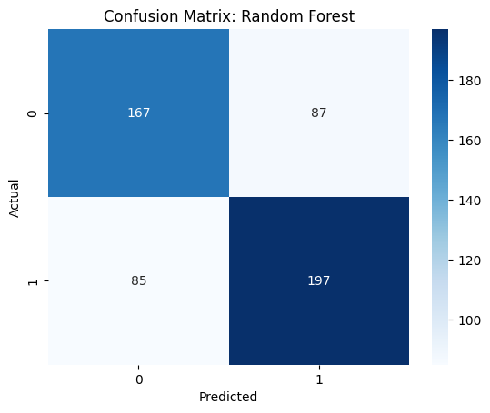

```python
evaluate_model("Random Forest", y_test, rf_preds)
```

```
🧪 Evaluation for XGBoost:
Accuracy : 0.6585820895522388
F1 Score : 0.6772486772486772
Precision: 0.6736842105263158
Recall   : 0.6808510638297872

Classification Report:
               precision    recall  f1-score   support

           0       0.64      0.63      0.64       254
           1       0.67      0.68      0.68       282

    accuracy                           0.66       536
   macro avg       0.66      0.66      0.66       536
weighted avg       0.66      0.66      0.66       536
```

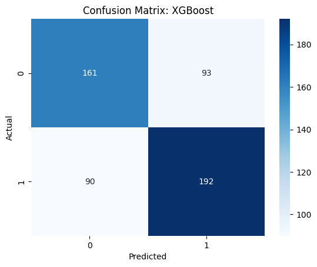

```python
evaluate_model("XGBoost", y_test, xgb_preds)
```

```
🧪 Evaluation for gridsearch:
Accuracy : 0.6902985074626866
F1 Score : 0.7195945945945946
Precision: 0.6870967741935484
Recall   : 0.7553191489361702

Classification Report:
               precision    recall  f1-score   support

           0       0.69      0.62      0.65       254
           1       0.69      0.76      0.72       282

    accuracy                           0.69       536
   macro avg       0.69      0.69      0.69       536
weighted avg       0.69      0.69      0.69       536
```

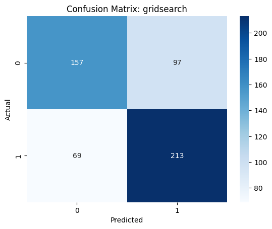

```python
evaluate_model("gridsearch", y_test, grid_pred_SVC2)
```

```
🧪 Evaluation for SGDClassifier:
Accuracy : 0.6791044776119403
F1 Score : 0.7054794520547946
Precision: 0.6821192052980133
Recall   : 0.7304964539007093

Classification Report:
               precision    recall  f1-score   support

           0       0.68      0.62      0.65       254
           1       0.68      0.73      0.71       282

    accuracy                           0.68       536
   macro avg       0.68      0.68      0.68       536
weighted avg       0.68      0.68      0.68       536
```

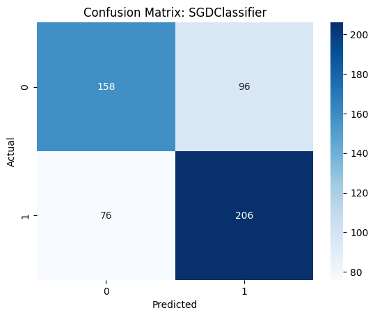

```python
evaluate_model("SGDClassifier", y_test, grid_pred_SGDC)
```

```
🧪 Evaluation for Logistic Regression:
Accuracy : 0.6716417910447762
F1 Score : 0.6890459363957597
Precision: 0.6866197183098591
Recall   : 0.6914893617021277

Classification Report:
               precision    recall  f1-score   support

           0       0.65      0.65      0.65       254
           1       0.69      0.69      0.69       282

    accuracy                           0.67       536
   macro avg       0.67      0.67      0.67       536
weighted avg       0.67      0.67      0.67       536
```

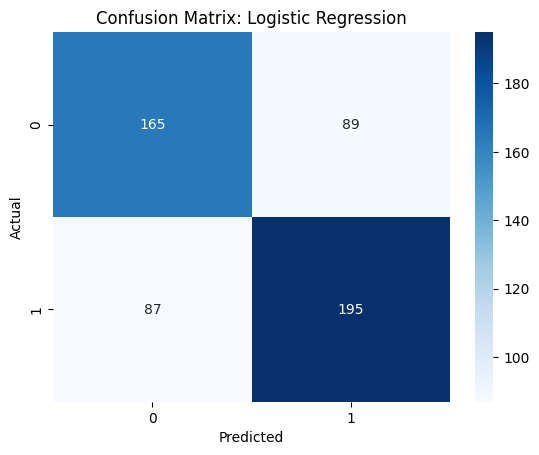

```python
evaluate_model("Logistic Regression", y_test, log_pred)
```

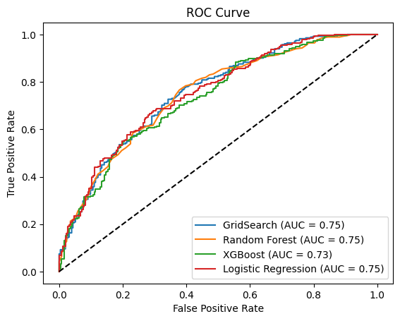

```python
rf_probs = rf_model.predict_proba(X_test)[:, 1]
xgb_probs = xgb_model.predict_proba(X_test)[:, 1]
grid_probs = grid_svc2.predict_proba(X_test_scaled)[:,1]
log_probs = log_model.predict_proba(X_test_scaled)[:,1]

fpr_grid, tpr_grid, _ = roc_curve(y_test, grid_probs)
fpr_rf, tpr_rf, _ = roc_curve(y_test, rf_probs)
fpr_xgb, tpr_xgb, _ = roc_curve(y_test, xgb_probs)
fpr_log, tpr_log, _ = roc_curve(y_test, log_probs)

plt.plot(fpr_grid, tpr_grid, label='GridSearch (AUC = {:.2f})'.format(roc_auc_score(y_test, grid_probs)))
plt.plot(fpr_rf, tpr_rf, label='Random Forest (AUC = {:.2f})'.format(roc_auc_score(y_test, rf_probs)))
plt.plot(fpr_xgb, tpr_xgb, label='XGBoost (AUC = {:.2f})'.format(roc_auc_score(y_test, xgb_probs)))
plt.plot(fpr_log, tpr_log, label='Logistic Regression (AUC = {:.2f})'.format(roc_auc_score(y_test, log_probs)))
plt.plot([0, 1], [0, 1], 'k--')  # Diagonal line
plt.xlabel('False Positive Rate')
plt.ylabel('True Positive Rate')
plt.title('ROC Curve')
plt.legend()
plt.show()
```

##### There is still significant work to be done to improve the model’s accuracy. Future efforts could focus on additional feature engineering to strengthen weakly correlated features or remove irrelevant ones altogether. Incorporating new variables, such as weather conditions and player injuries, may also provide deeper insight into team performance and further enhance prediction accuracy.